# The Effect of Wildfire Smoke on Academic Achievement

Simon Woodcock  
CREA 2026

Discussant: James Ji

University of Guelph

September 2026

## What the paper does

- Effect of wildfire smoke on reading and numeracy, B.C. grades 4 and 7
- Population of B.C. public and independent school students, 2010/11-2021/22:
  - Foundation Skills Assessment (FSA) scores
  - Parents’ income (T1FF tax files)
  - Heavy-smoke days (NOAA HMS) and smoke PM2.5 (CanOSSEM), by six-digit postal code
- Identification: year-to-year variation in smoke within postal codes
  - Falsification: future smoke; excluding students near fire perimeters
- Ten heavy-smoke days in the 12 months before the test lower scores by 0.03-0.05 SD
  - Concentrated among boys; summer timing read as a physiological channel

## Wildfire smoke, policy and the literature

Policy

- Since 2016, smoke eroded 23% of prior PM2.5 gains in two-thirds of U.S. states (Burke et al. 2023)
- 2023 Canadian fires: +3.8 µg/m³ national annual-mean PM2.5; 64,300 chronic deaths (Zhang et al. 2025)
- Documented costs of smoke: earnings, emergency visits, suicide (Borgschulte et al. 2024; Heft-Neal et al. 2023; Molitor et al. 2023)

Literature

- Air pollution and learning (a fairly large literature):
  - Exam day (Ebenstein et al. 2016; Graff Zivin et al. 2020)
  - School year (Heissel et al. 2022; Gilraine and Zheng 2024)
  - Prenatal (Sanders 2012; Bharadwaj et al. 2017)
- Wildfire smoke and achievement: Wen and Burke (2022); Behrer et al. (2026); Arrizaga et al. (2026)
- Open question: lasting human capital or transient performance?

## Magnitude and positioning

- Per µg/m³-day, of similar magnitude to Wen and Burke (2022) and Gilraine and Zheng (2024)
  - One B.C. heavy-smoke day = about 65 µg/m³-days of smoke PM2.5
  - Ten heavy days = about 19 average U.S. district smoke-years
- No sign of a smoke-specific toxicity premium for test scores
- Individual-level data now also in Behrer et al. (2026): about 10 million U.S. PSAT takers
- Build the contribution on what studying BC adds to the literature:
  - Extreme doses, above Behrer et al.’s moderate days (8-12 µg/m³)
  - The 2017 test-timing reform
  - A monetized Canadian human-capital cost

## The summer puzzle

- Smoke arrives in July-August, when school is out, yet tests are administered in fall/winter
- How can summer exposure enter grades?
- School-year exposure has a clear channel:
  - Smoke PM2.5: the effect comes from school-year days (Behrer et al. 2026)
  - Closures and absences on smoke days (Graff Zivin and Lee 2026)
  - Heat: school-year heat lowers learning; summer heat does little (Park et al. 2020)
- Summer smoke lowers next-year GPA in Chile, with no identifiable attendance effect (Arrizaga et al. 2026)
- The paper’s own timing: effect 2-4 months after the season, none at 5-7 months

## The summer puzzle: evidence from U.S. data

Behrer et al. (2026): U.S. PSAT retakes

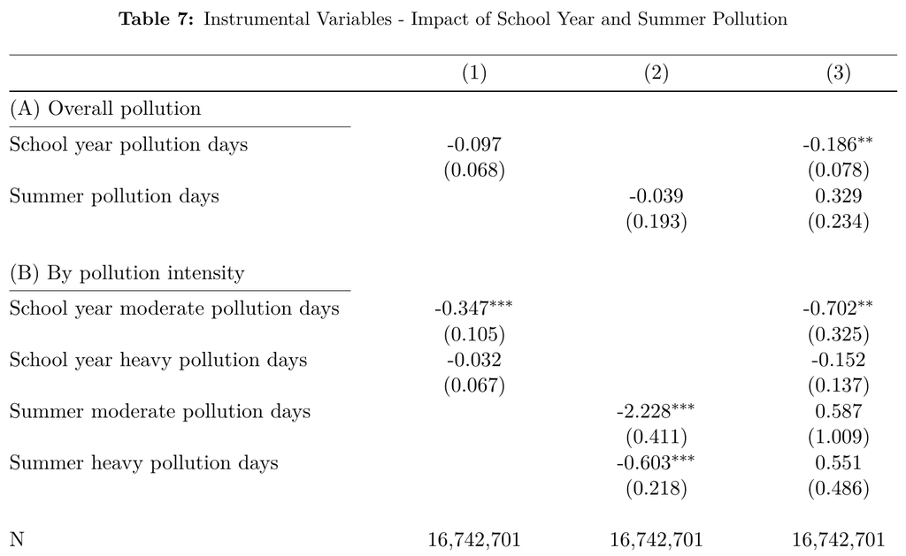

Panel B: summer days statistically significant alone (col. 2); statistically insignificant once school-year days enter (col. 3). Source: Behrer et al. (2026), Table 7

Graff Zivin and Lee (2026): closures (CA), attendance (TX)

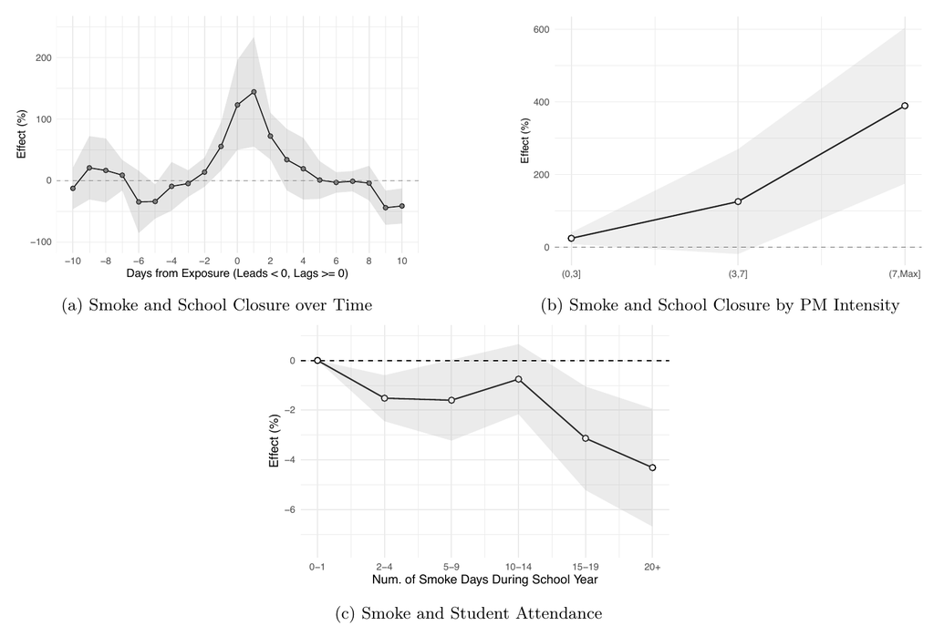

## Check summer vs. school-year exposure?

- Does ANY smoke day overlap with the school year?
- Split exposure into September and July-August days, entered jointly
- Monthly distributed lag by months before the test, pooling both testing regimes

## Candidate mechanisms for summer exposure

- Physiological: respiratory illness, inflammation
  - Larger for students with a chronic-health designation?
- Psychological: child mental health, stronger for boys (Zhang et al. 2026)
  - Mental-health designations: precisely estimated zeros, though they respond to parental earnings losses (Jones et al. 2024)
- Disrupted summer: children indoors, lost summer camp
  - Not sure how much summer camp attendance correlates with school grades
- Household income: smoke lowers parents’ earnings (Borgschulte et al. 2024)
  - Smoke effect on parental earnings through T1 filing?